# Amazon Sales Data

Description:

```python
# for remove warning
import warnings
warnings.filterwarnings("ignore")
```

Libraries were used for this EDA analysyis

```python
import pandas as pd
import numpy as np
import matplotlib.pyplot as plt
import seaborn as sns
```

```python
df= pd.read_csv("amazon.csv")
df.head(5)
```

|  | product_id | product_name | category | discounted_price | actual_price | discount_percentage | rating | rating_count | about_product | user_id | user_name | review_id | review_title | review_content | img_link | product_link |
| --- | --- | --- | --- | --- | --- | --- | --- | --- | --- | --- | --- | --- | --- | --- | --- | --- |
| 0 | B07JW9H4J1 | Wayona Nylon Braided USB to Lightning Fast Cha... | Computers&Accessories\|Accessories&Peripherals\|... | ₹399 | ₹1,099 | 64% | 4.2 | 24,269 | High Compatibility : Compatible With iPhone 12... | AG3D6O4STAQKAY2UVGEUV46KN35Q,AHMY5CWJMMK5BJRBB... | Manav,Adarsh gupta,Sundeep,S.Sayeed Ahmed,jasp... | R3HXWT0LRP0NMF,R2AJM3LFTLZHFO,R6AQJGUP6P86,R1K... | Satisfied,Charging is really fast,Value for mo... | Looks durable Charging is fine tooNo complains... | https://m.media-amazon.com/images/W/WEBP_40237... | https://www.amazon.in/Wayona-Braided-WN3LG1-Sy... |
| 1 | B098NS6PVG | Ambrane Unbreakable 60W / 3A Fast Charging 1.5... | Computers&Accessories\|Accessories&Peripherals\|... | ₹199 | ₹349 | 43% | 4.0 | 43,994 | Compatible with all Type C enabled devices, be... | AECPFYFQVRUWC3KGNLJIOREFP5LQ,AGYYVPDD7YG7FYNBX... | ArdKn,Nirbhay kumar,Sagar Viswanathan,Asp,Plac... | RGIQEG07R9HS2,R1SMWZQ86XIN8U,R2J3Y1WL29GWDE,RY... | A Good Braided Cable for Your Type C Device,Go... | I ordered this cable to connect my phone to An... | https://m.media-amazon.com/images/W/WEBP_40237... | https://www.amazon.in/Ambrane-Unbreakable-Char... |
| 2 | B096MSW6CT | Sounce Fast Phone Charging Cable & Data Sync U... | Computers&Accessories\|Accessories&Peripherals\|... | ₹199 | ₹1,899 | 90% | 3.9 | 7,928 | 【 Fast Charger& Data Sync】-With built-in safet... | AGU3BBQ2V2DDAMOAKGFAWDDQ6QHA,AESFLDV2PT363T2AQ... | Kunal,Himanshu,viswanath,sai niharka,saqib mal... | R3J3EQQ9TZI5ZJ,R3E7WBGK7ID0KV,RWU79XKQ6I1QF,R2... | Good speed for earlier versions,Good Product,W... | Not quite durable and sturdy,https://m.media-a... | https://m.media-amazon.com/images/W/WEBP_40237... | https://www.amazon.in/Sounce-iPhone-Charging-C... |
| 3 | B08HDJ86NZ | boAt Deuce USB 300 2 in 1 Type-C & Micro USB S... | Computers&Accessories\|Accessories&Peripherals\|... | ₹329 | ₹699 | 53% | 4.2 | 94,363 | The boAt Deuce USB 300 2 in 1 cable is compati... | AEWAZDZZJLQUYVOVGBEUKSLXHQ5A,AG5HTSFRRE6NL3M5S... | Omkar dhale,JD,HEMALATHA,Ajwadh a.,amar singh ... | R3EEUZKKK9J36I,R3HJVYCLYOY554,REDECAZ7AMPQC,R1... | Good product,Good one,Nice,Really nice product... | Good product,long wire,Charges good,Nice,I bou... | https://m.media-amazon.com/images/I/41V5FtEWPk... | https://www.amazon.in/Deuce-300-Resistant-Tang... |
| 4 | B08CF3B7N1 | Portronics Konnect L 1.2M Fast Charging 3A 8 P... | Computers&Accessories\|Accessories&Peripherals\|... | ₹154 | ₹399 | 61% | 4.2 | 16,905 | [CHARGE & SYNC FUNCTION]- This cable comes wit... | AE3Q6KSUK5P75D5HFYHCRAOLODSA,AFUGIFH5ZAFXRDSZH... | rahuls6099,Swasat Borah,Ajay Wadke,Pranali,RVK... | R1BP4L2HH9TFUP,R16PVJEXKV6QZS,R2UPDB81N66T4P,R... | As good as original,Decent,Good one for second... | Bought this instead of original apple, does th... | https://m.media-amazon.com/images/W/WEBP_40237... | https://www.amazon.in/Portronics-Konnect-POR-1... |

```python
df.columns
```

```
Index(['product_id', 'product_name', 'category', 'discounted_price',
       'actual_price', 'discount_percentage', 'rating', 'rating_count',
       'about_product', 'user_id', 'user_name', 'review_id', 'review_title',
       'review_content', 'img_link', 'product_link'],
      dtype='object')
```

Before analyzing the data lets check if there are any null or missing values in our dataset

```python
df.isnull().sum()
```

```
product_id             0
product_name           0
category               0
discounted_price       0
actual_price           0
discount_percentage    0
rating                 0
rating_count           2
about_product          0
user_id                0
user_name              0
review_id              0
review_title           0
review_content         0
img_link               0
product_link           0
dtype: int64
```

Replace Null Value and change data types

```python
df['actual_price'] = df['actual_price'].str.replace('₹','')
df['actual_price'] = df['actual_price'].str.replace(',','').astype('float64')

df['discounted_price'] = df['discounted_price'].str.replace('₹','')
df['discounted_price'] = df['discounted_price'].str.replace(',','').astype('float64')
df['discount_percentage'] = df['discount_percentage'].str.replace('%','').astype('float64')
df['discount_percentage'] = df['discount_percentage']/100
df['rating_count'] = df['rating_count'].str.replace(',','').astype('float64')
df['rating'].value_counts()
```

```
rating
4.1    244
4.3    230
4.2    228
4.0    129
3.9    123
4.4    123
3.8     86
4.5     75
4       52
3.7     42
3.6     35
3.5     26
4.6     17
3.3     16
3.4     10
4.7      6
3.1      4
5.0      3
3.0      3
4.8      3
3.2      2
2.8      2
2.3      1
|        1
2        1
3        1
2.6      1
2.9      1
Name: count, dtype: int64
```

```python
df['rating'].value_counts()
```

```
rating
4.1    244
4.3    230
4.2    228
4.0    129
3.9    123
4.4    123
3.8     86
4.5     75
4       52
3.7     42
3.6     35
3.5     26
4.6     17
3.3     16
3.4     10
4.7      6
3.1      4
5.0      3
3.0      3
4.8      3
3.2      2
2.8      2
2.3      1
|        1
2        1
3        1
2.6      1
2.9      1
Name: count, dtype: int64
```

```python
# To check the rating colume where rating == |
df[df['rating']=='|']
```

|  | product_id | product_name | category | discounted_price | actual_price | discount_percentage | rating | rating_count | about_product | user_id | user_name | review_id | review_title | review_content | img_link | product_link |
| --- | --- | --- | --- | --- | --- | --- | --- | --- | --- | --- | --- | --- | --- | --- | --- | --- |
| 1279 | B08L12N5H1 | Eureka Forbes car Vac 100 Watts Powerful Sucti... | Home&Kitchen\|Kitchen&HomeAppliances\|Vacuum,Cle... | 2099.0 | 2499.0 | 0.16 | \| | 992.0 | No Installation is provided for this product\|1... | AGTDSNT2FKVYEPDPXAA673AIS44A,AER2XFSWNN4LAUCJ5... | Divya,Dr Nefario,Deekshith,Preeti,Prasanth R,P... | R2KKTKM4M9RDVJ,R1O692MZOBTE79,R2WRSEWL56SOS4,R... | Decent product,doesn't pick up sand,Ok ok,Must... | Does the job well,doesn't work on sand. though... | https://m.media-amazon.com/images/W/WEBP_40237... | https://www.amazon.in/Eureka-Forbes-Vacuum-Cle... |

```python
# Replace '|' with '4.0' in the 'rating' column
df['rating'] = df['rating'].str.replace('|','4.0').astype('float64')
df['rating'].value_counts()
```

```
rating
4.1    244
4.3    230
4.2    228
4.0    182
3.9    123
4.4    123
3.8     86
4.5     75
3.7     42
3.6     35
3.5     26
4.6     17
3.3     16
3.4     10
4.7      6
3.0      4
3.1      4
5.0      3
4.8      3
3.2      2
2.8      2
2.3      1
2.0      1
2.6      1
2.9      1
Name: count, dtype: int64
```

```python
len(df['rating'])
```

```
1465
```

```python
df.dtypes
```

```
product_id              object
product_name            object
category                object
discounted_price       float64
actual_price           float64
discount_percentage    float64
rating                 float64
rating_count           float64
about_product           object
user_id                 object
user_name               object
review_id               object
review_title            object
review_content          object
img_link                object
product_link            object
dtype: object
```

```python
#check for num of rows and columns
df.shape
```

```
(1465, 16)
```

```python
#Create new data frame with selected columns
#df1 = df[['product_id', 'product_name', 'category', 'discounted_price', 'actual_price', 'discount_percentage', 'rating', 'rating_count']].copy()
```

Split category column

```python
categorial_split = df['category'].str.split('|', expand=True)
categorial_split.isnull().sum()
```

```
0       0
1       0
2       8
3     165
4     943
5    1380
6    1452
dtype: int64
```

Rename column

```python
categorial_split = categorial_split.rename(columns={0:'Category', 1:'Sub category'})
```

Add new cols to data frame and drop the old ones

```python
df['Category'] = categorial_split['Category']
df['Sub category'] = categorial_split['Sub category']
df.drop(columns ='category', inplace=True)
df
```

[output not shown]

```python
#Fixing the strings in Main category
df['Category'].value_counts()
```

```
Category
Electronics              526
Computers&Accessories    453
Home&Kitchen             448
OfficeProducts            31
MusicalInstruments         2
HomeImprovement            2
Toys&Games                 1
Car&Motorbike              1
Health&PersonalCare        1
Name: count, dtype: int64
```

```python
df['Category'] = df['Category'].str.replace('&', ' & ')
df['Category'] = df['Category'].str.replace('OfficeProducts', 'Office Products')
df['Category'] = df['Category'].str.replace('MusicalInstruments', 'Musical Instruments')
df['Category'] = df['Category'].str.replace('HomeImprovement', 'Home Improvement')
```

Fixing string with Sub category

```python
df['Sub category'].value_counts()
```

```
Sub category
Accessories&Peripherals                    381
Kitchen&HomeAppliances                     308
HomeTheater,TV&Video                       162
Mobiles&Accessories                        161
Heating,Cooling&AirQuality                 116
WearableTechnology                          76
Headphones,Earbuds&Accessories              66
NetworkingDevices                           34
OfficePaperProducts                         27
ExternalDevices&DataStorage                 18
Cameras&Photography                         16
HomeStorage&Organization                    16
HomeAudio                                   16
GeneralPurposeBatteries&BatteryChargers     14
Accessories                                 14
Printers,Inks&Accessories                   11
CraftMaterials                               7
Components                                   5
OfficeElectronics                            4
Electrical                                   2
Monitors                                     2
Microphones                                  2
Arts&Crafts                                  1
PowerAccessories                             1
Tablets                                      1
Laptops                                      1
Kitchen&Dining                               1
CarAccessories                               1
HomeMedicalSupplies&Equipment                1
Name: count, dtype: int64
```

```python
df1['Sub category'] = df1['Sub category'].str.replace('&', ' & ')
df1['Sub category'] = df1['Sub category'].str.replace(',', ', ')
df1['Sub category'] = df1['Sub category'].str.replace('HomeAppliances', 'Home Appliances')
df1['Sub category'] = df1['Sub category'].str.replace('AirQuality', 'Air Quality')
df1['Sub category'] = df1['Sub category'].str.replace('WearableTechnology', 'Wearable Technology')
df1['Sub category'] = df1['Sub category'].str.replace('NetworkingDevices', 'Networking Devices')
df1['Sub category'] = df1['Sub category'].str.replace('OfficePaperProducts', 'Office Paper Products')
df1['Sub category'] = df1['Sub category'].str.replace('ExternalDevices', 'External Devices')
df1['Sub category'] = df1['Sub category'].str.replace('DataStorage', 'Data Storage')
df1['Sub category'] = df1['Sub category'].str.replace('HomeStorage', 'Home Storage')
df1['Sub category'] = df1['Sub category'].str.replace('HomeAudio', 'Home Audio')
df1['Sub category'] = df1['Sub category'].str.replace('GeneralPurposeBatteries', 'General Purpose Batteries')
df1['Sub category'] = df1['Sub category'].str.replace('BatteryChargers', 'Battery Chargers')
df1['Sub category'] = df1['Sub category'].str.replace('CraftMaterials', 'Craft Materials')
df1['Sub category'] = df1['Sub category'].str.replace('OfficeElectronics', 'Office Electronics')
df1['Sub category'] = df1['Sub category'].str.replace('PowerAccessories', 'Power Accessories')
df1['Sub category'] = df1['Sub category'].str.replace('CarAccessories', 'Car Accessories')
df1['Sub category'] = df1['Sub category'].str.replace('HomeMedicalSupplies', 'Home Medical Supplies')
df1['Sub category'] = df1['Sub category'].str.replace('HomeTheater', 'Home Theater')
```

```python
df.head()
```

[output not shown]

1 What is the average rating for each product category?

```python
average_rating_per_category= df.groupby('Category')['rating'].mean().reset_index()

# Rename the columns for better readability
average_rating_per_category.columns = ['Product Category', 'Average Rating']

# Format the 'Average Rating' column to 2 decimal places
average_rating_per_category['Average Rating'] = average_rating_per_category['Average Rating'].round(2)


# Print the result
print(average_rating_per_category)
```

```
          Product Category  Average Rating
0          Car & Motorbike            3.80
1  Computers & Accessories            4.15
2              Electronics            4.08
3    Health & PersonalCare            4.00
4           Home & Kitchen            4.04
5         Home Improvement            4.25
6      Musical Instruments            3.90
7          Office Products            4.31
8             Toys & Games            4.30
```

What are the top rating_count products by category?

```python
#Group by category and sub_category , then count the number of rating of each product
rating_count_by_product= df.groupby(['Category','Sub category'])['rating'].count().reset_index()

# Rename the columns for better readability
rating_count_by_product.columns = ['Product Category', 'Product Sub Category', 'Rating Count']

# Sort the products within each category by rating count in descending order
rating_count_by_product = rating_count_by_product.sort_values(['Product Category', 'Rating Count'], ascending=[True, False])

# Find the top product by rating count for each category
top_products_by_category = rating_count_by_product.groupby('Product Category').head(1)

# Print the result
print(top_products_by_category)
```

```
           Product Category           Product Sub Category  Rating Count
0           Car & Motorbike                 CarAccessories             1
1   Computers & Accessories        Accessories&Peripherals           381
14              Electronics           HomeTheater,TV&Video           162
18    Health & PersonalCare  HomeMedicalSupplies&Equipment             1
23           Home & Kitchen         Kitchen&HomeAppliances           308
24         Home Improvement                     Electrical             2
25      Musical Instruments                    Microphones             2
27          Office Products            OfficePaperProducts            27
28             Toys & Games                    Arts&Crafts             1
```

```python
#Group by category and sub_category , then count the number of rating of each product
rating_count_by_product= df.groupby('Category')['rating'].count().reset_index()

# Rename the columns for better readability
rating_count_by_product.columns = ['Product Category', 'Rating Count']

# Sort the products within each category by rating count in descending order
rating_count_by_product = rating_count_by_product.sort_values(['Product Category', 'Rating Count'], ascending=[True, False])

# Find the top product by rating count for each category
top_products_by_category = rating_count_by_product.groupby('Product Category').head(1)

# Print the result
print(top_products_by_category)
```

```
          Product Category  Rating Count
0          Car & Motorbike             1
1  Computers & Accessories           453
2              Electronics           526
3    Health & PersonalCare             1
4           Home & Kitchen           448
5         Home Improvement             2
6      Musical Instruments             2
7          Office Products            31
8             Toys & Games             1
```

What is the distribution of discounted prices vs. actual prices?

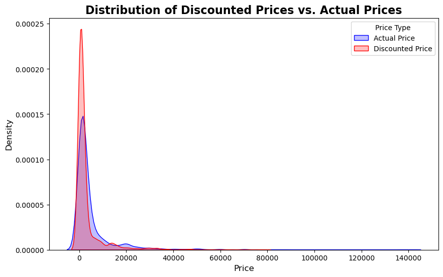

```python
# Plot the distributions of actual_price and discounted_price
plt.figure(figsize=(10, 6))

# Plot the actual prices distribution
sns.kdeplot(df['actual_price'], label='Actual Price', color='blue', shade=True, bw_adjust=0.7)

# Plot the discounted prices distribution
sns.kdeplot(df['discounted_price'], label='Discounted Price', color='red', shade=True, bw_adjust=0.7)

# Add title and labels
plt.title('Distribution of Discounted Prices vs. Actual Prices', fontsize=16, fontweight='bold')
plt.xlabel('Price', fontsize=12)
plt.ylabel('Density', fontsize=12)
plt.legend(title='Price Type')

# Show the plot
plt.show()
```

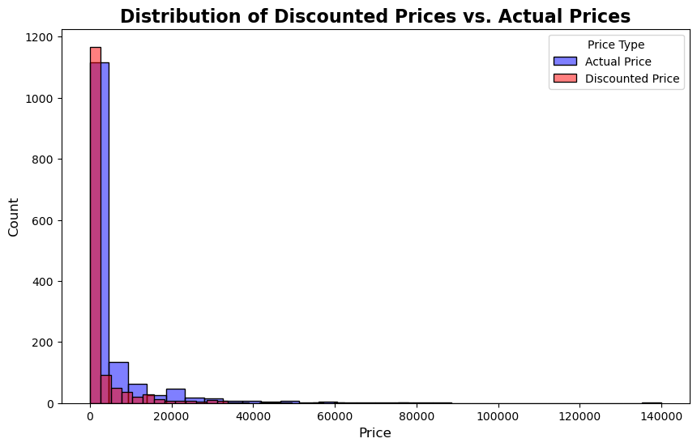

```python
plt.figure(figsize=(10, 6))

# Plot the actual prices distribution
sns.histplot(df['actual_price'], label='Actual Price', color='blue', bins=30, alpha=0.5)

# Plot the discounted prices distribution
sns.histplot(df['discounted_price'], label='Discounted Price', color='red', bins=30, alpha=0.5)

# Add title and labels
plt.title('Distribution of Discounted Prices vs. Actual Prices', fontsize=16, fontweight='bold')
plt.xlabel('Price', fontsize=12)
plt.ylabel('Count', fontsize=12)
plt.legend(title='Price Type')

# Show the plot
plt.show()
```

How does the average discount percentage vary across categories?

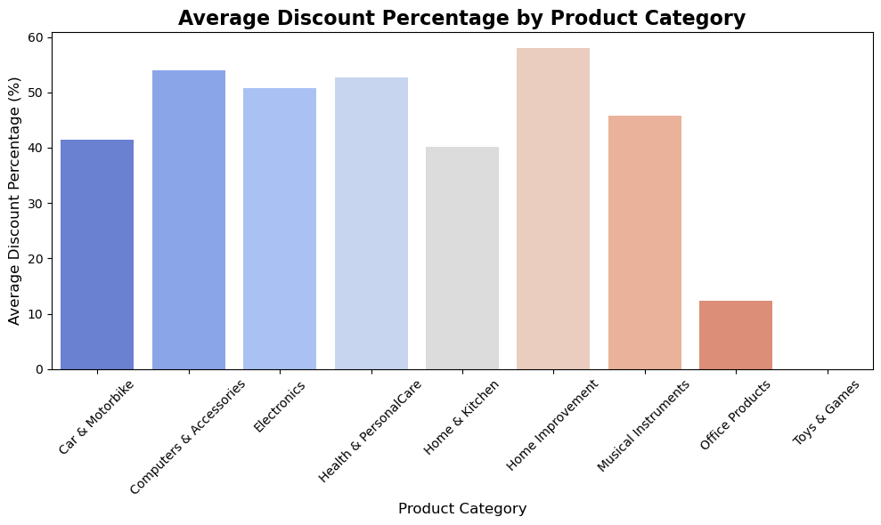

```python
# Calculate the discount percentage
df['discount_percentage'] = ((df['actual_price'] - df['discounted_price']) / df['actual_price']) * 100

# Group by product category and calculate the average discount percentage
avg_discount_by_category = df.groupby('Category')['discount_percentage'].mean().reset_index()

# Rename columns for clarity
avg_discount_by_category.columns = ['Product Category', 'Average Discount Percentage']

# Plot the average discount percentage across categories
plt.figure(figsize=(10, 6))
sns.barplot(x='Product Category', y='Average Discount Percentage', data=avg_discount_by_category, palette='coolwarm')

# Add title and labels
plt.title('Average Discount Percentage by Product Category', fontsize=16, fontweight='bold')
plt.xlabel('Product Category', fontsize=12)
plt.ylabel('Average Discount Percentage (%)', fontsize=12)
plt.xticks(rotation=45)

# Show the plot
plt.tight_layout()
plt.show()
```

What are the most popular product names?

```python
# Count the number of occurrences of each product
product_counts = df['product_name'].value_counts().reset_index()
product_counts.columns = ['Product Name', 'Count']

# Print the most popular products
print(product_counts.head(1))
```

```
                                        Product Name  Count
0  Fire-Boltt Ninja Call Pro Plus 1.83" Smart Wat...      5
```

6.What are the most popular product keywords?

```
        Keyword  Count
8255       good   6522
13153   product   4396
13445   quality   2779
4299      cable   2713
17263       use   2320
17254       usb   2056
4645   charging   1919
6723       easy   1584
10327      like   1428
13049     price   1404
```

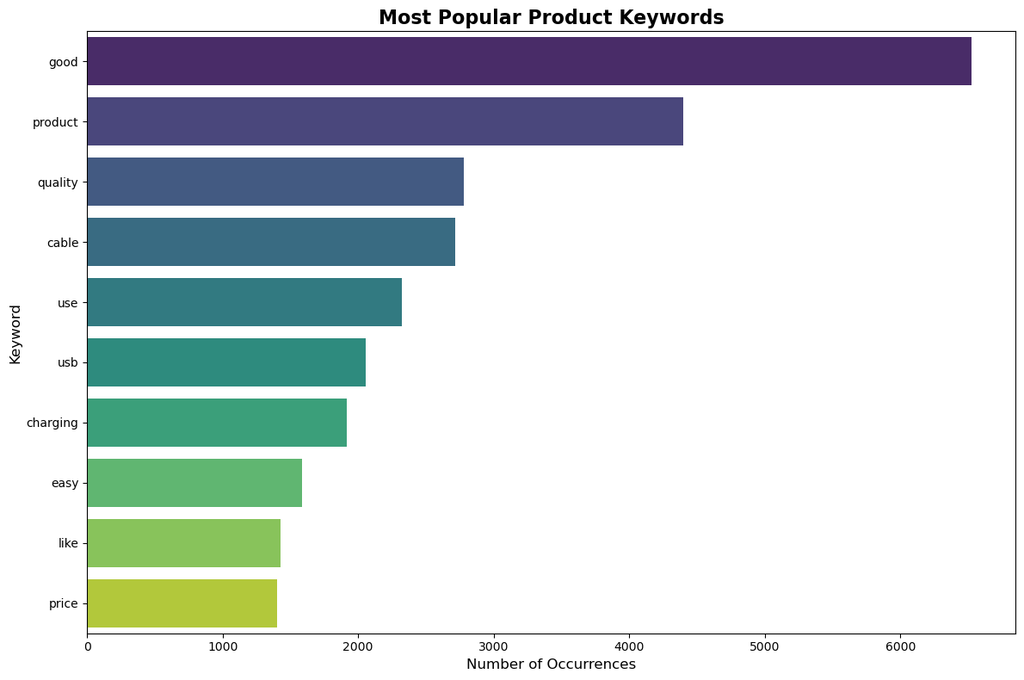

```python
from sklearn.feature_extraction.text import CountVectorizer
# Assuming 'df' is your DataFrame containing relevant columns
# Combine text data from multiple columns into a single Series
df['combined_text'] = df['product_name'].fillna('') + ' ' + df['about_product'].fillna('') + ' ' + df['review_content'].fillna('')

# Initialize CountVectorizer to tokenize words and remove stop words
vectorizer = CountVectorizer(stop_words='english')

# Fit and transform the combined text data
X = vectorizer.fit_transform(df['combined_text'])

# Get feature names and sum the occurrences of each word
word_counts = X.sum(axis=0).A1
words = vectorizer.get_feature_names_out()

# Create a DataFrame for the words and their counts
keyword_counts = pd.DataFrame({'Keyword': words, 'Count': word_counts})

# Sort the keywords by count in descending order
keyword_counts = keyword_counts.sort_values(by='Count', ascending=False)

# Print the most popular keywords
print(keyword_counts.head(10))

# Plot the most popular keywords
plt.figure(figsize=(12, 8))
sns.barplot(x='Count', y='Keyword', data=keyword_counts.head(10), palette='viridis')

# Add title and labels
plt.title('Most Popular Product Keywords', fontsize=16, fontweight='bold')
plt.xlabel('Number of Occurrences', fontsize=12)
plt.ylabel('Keyword', fontsize=12)

# Show the plot
plt.tight_layout()
plt.show()
```

7. What are the most popular product reviews?

```python
#Count the Number of Reviews per Product

# Count the number of reviews per product
reviews_count = df['product_id'].value_counts().reset_index()
reviews_count.columns = ['Product ID', 'Number of Reviews']

# Print the most reviewed products
print(reviews_count.head(10))
```

```
   Product ID  Number of Reviews
0  B07JW9H4J1                  3
1  B085DTN6R2                  3
2  B07XLCFSSN                  3
3  B077Z65HSD                  3
4  B09W5XR9RT                  3
5  B082T6V3DT                  3
6  B09NHVCHS9                  3
7  B09YLXYP7Y                  3
8  B09C6HXFC1                  3
9  B08R69VDHT                  3
```

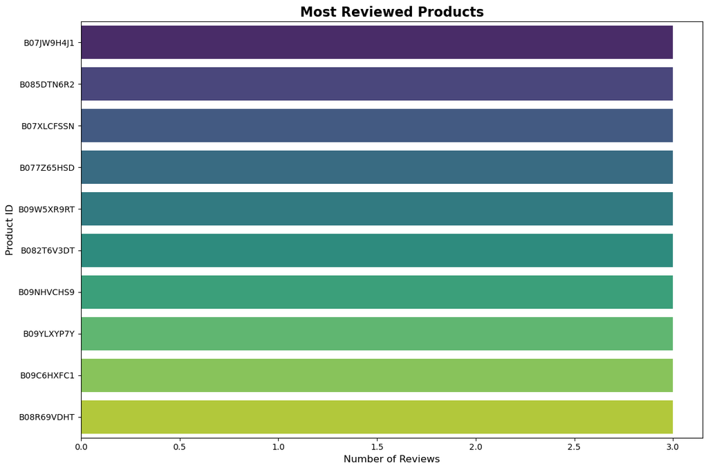

```python
import seaborn as sns
import matplotlib.pyplot as plt

# Assuming you want to visualize the most reviewed products
plt.figure(figsize=(12, 8))
sns.barplot(x='Number of Reviews', y='Product ID', data=reviews_count.head(10), palette='viridis')

# Add title and labels
plt.title('Most Reviewed Products', fontsize=16, fontweight='bold')
plt.xlabel('Number of Reviews', fontsize=12)
plt.ylabel('Product ID', fontsize=12)

# Show the plot
plt.tight_layout()
plt.show()
```

What is the correlation between discounted_price and rating?

```
Pearson correlation coefficient: 0.12
```

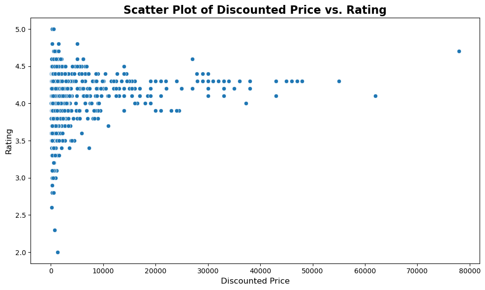

```python
# Calculate the Pearson correlation coefficient
correlation = df_cleaned['discounted_price'].corr(df_cleaned['rating'])
print(f"Pearson correlation coefficient: {correlation:.2f}")

# Optional: Visualize the relationship with a scatter plot
plt.figure(figsize=(10, 6))
sns.scatterplot(x='discounted_price', y='rating', data=df_cleaned, palette='viridis')

# Add titles and labels
plt.title('Scatter Plot of Discounted Price vs. Rating', fontsize=16, fontweight='bold')
plt.xlabel('Discounted Price', fontsize=12)
plt.ylabel('Rating', fontsize=12)

# Show the plot
plt.tight_layout()
plt.show()
```

Interpretation:

- Positive Correlation: If the correlation coefficient is close to 1, higher discounted prices tend to be associated with higher ratings.
- Negative Correlation: If the coefficient is close to -1, higher discounted prices tend to be associated with lower ratings.
- No Correlation: A coefficient near 0 suggests no significant linear relationship between discounted price and rating.
9. What are the Top 5 categories based on the highest ratings?

```python
# Calculate the average rating for each category
avg_ratings_by_category = df.groupby('Category')['rating'].mean().reset_index()

# Sort categories by average rating in descending order
avg_ratings_by_category = avg_ratings_by_category.sort_values(by='rating', ascending=False)

# Select the top 5 categories
top_5_categories = avg_ratings_by_category.head(5)

# Print the top 5 categories with highest ratings
print(top_5_categories)
```

```
                  Category    rating
7          Office Products  4.309677
8             Toys & Games  4.300000
5         Home Improvement  4.250000
1  Computers & Accessories  4.154967
2              Electronics  4.081749
```

```python
df.columns
```

```
Index(['product_id', 'product_name', 'discounted_price', 'actual_price',
       'discount_percentage', 'rating', 'rating_count', 'about_product',
       'user_id', 'user_name', 'review_id', 'review_title', 'review_content',
       'img_link', 'product_link', 'combined_text', 'Category',
       'Sub category'],
      dtype='object')
```

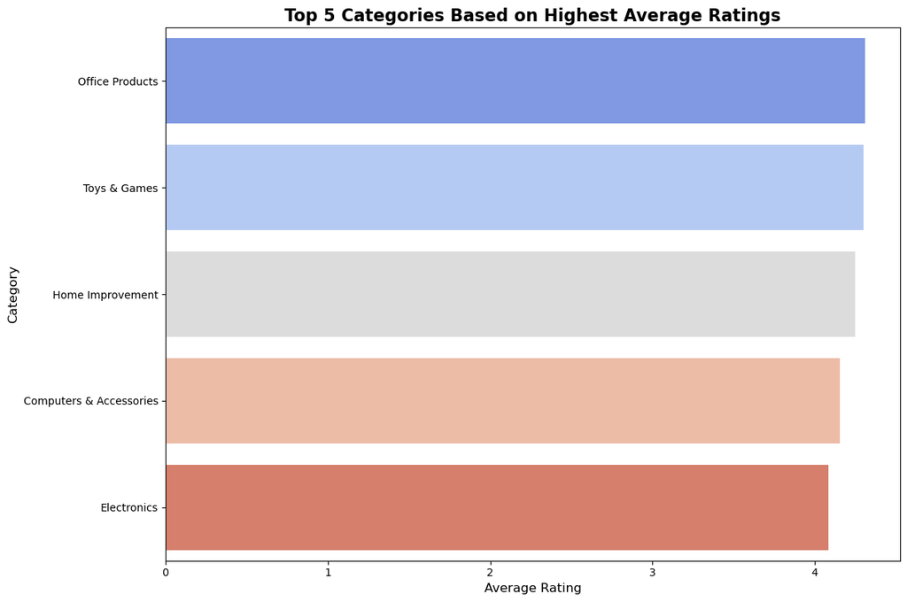

```python
# Plot the top 5 categories based on average rating
plt.figure(figsize=(12, 8))
sns.barplot(x='rating', y='Category', data=top_5_categories, palette='coolwarm')

# Add title and labels
plt.title('Top 5 Categories Based on Highest Average Ratings', fontsize=16, fontweight='bold')
plt.xlabel('Average Rating', fontsize=12)
plt.ylabel('Category', fontsize=12)

# Show the plot
plt.tight_layout()
plt.show()
```

```python
# Calculate the average rating for each category and subcategory
avg_ratings_by_category = df.groupby(['Category','Sub category'])['rating'].mean().reset_index()

# Sort categories by average rating in descending order
avg_ratings_by_category = avg_ratings_by_category.sort_values(by='rating', ascending=False)

# Select the top 5 categories
top_5_Sub_categories = avg_ratings_by_category.head(5)

# Print the top 5 categories with highest ratings
print(top_5_Sub_categories)
```

```
                   Category                             Sub category  rating
8   Computers & Accessories                                  Tablets    4.60
16              Electronics                         PowerAccessories    4.50
26          Office Products                        OfficeElectronics    4.45
2   Computers & Accessories                               Components    4.38
11              Electronics  GeneralPurposeBatteries&BatteryChargers    4.35
```

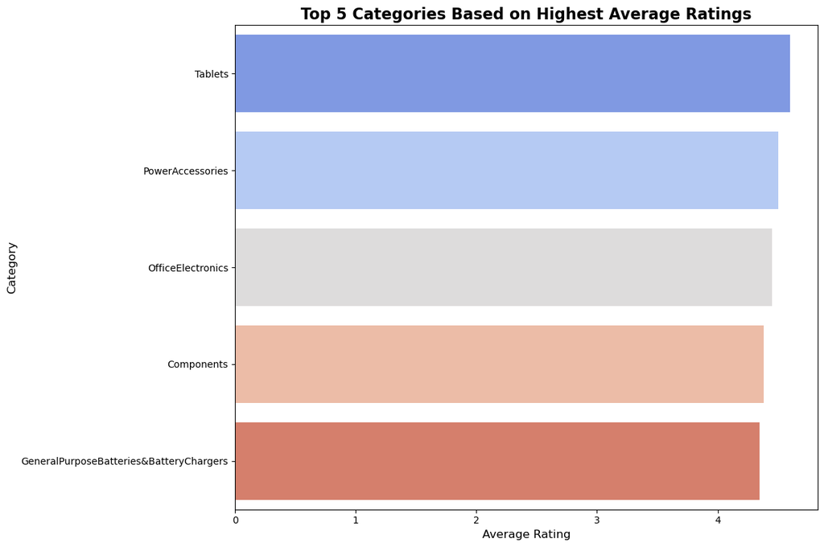

```python
# Plot the top 5 categories and Sub category based on average rating
plt.figure(figsize=(12, 8))
sns.barplot(x='rating', y='Sub category', data=top_5_Sub_categories, palette='coolwarm')

# Add title and labels
plt.title('Top 5 Categories Based on Highest Average Ratings', fontsize=16, fontweight='bold')
plt.xlabel('Average Rating', fontsize=12)
plt.ylabel('Category', fontsize=12)

# Show the plot
plt.tight_layout()
plt.show()
```

10. Identify any potential areas for improvement or optimization based on the data analysis.

```python
# Correlation between discounted price and rating
correlation = df['discounted_price'].corr(df['rating'])
print(f"Correlation between discounted price and rating: {correlation:.2f}")

# Average rating by category
avg_ratings_by_category = df.groupby('Category')['rating'].mean().reset_index()

# Identify categories with low average ratings
low_rated_categories = avg_ratings_by_category[avg_ratings_by_category['rating'] < avg_ratings_by_category['rating'].mean()]
print("Categories with below-average ratings:")
print(low_rated_categories)

# Analyzing review content for keywords (optional)
from sklearn.feature_extraction.text import CountVectorizer

# Initialize CountVectorizer
vectorizer = CountVectorizer(stop_words='english')
X = vectorizer.fit_transform(df['review_content'].fillna(''))
word_counts = X.sum(axis=0).A1
words = vectorizer.get_feature_names_out()
keyword_counts = pd.DataFrame({'Keyword': words, 'Count': word_counts})
keyword_counts = keyword_counts.sort_values(by='Count', ascending=False)
print("Most common review keywords:")
print(keyword_counts.head(10))
```

```
Correlation between discounted price and rating: 0.12
Categories with below-average ratings:
                Category    rating
0        Car & Motorbike  3.800000
2            Electronics  4.081749
3  Health & PersonalCare  4.000000
4         Home & Kitchen  4.040625
6    Musical Instruments  3.900000
Most common review keywords:
        Keyword  Count
5817       good   6455
9601    product   3947
9825    quality   2417
12825       use   1730
9507      price   1393
2756      cable   1380
7386       like   1243
9144      phone   1094
3027   charging   1010
12855     using   1006
```

- Address Product Issues: Focus on improving products with low ratings and leverage successful products for marketing and development.
- Optimize Pricing: Adjust pricing strategies based on the relationship between price, discount, and customer satisfaction.
- Improve Categories: Invest in high-performing categories and improve or reevaluate underperforming ones.
- Enhance Data Quality: Ensure data accuracy and completeness for more reliable insights.